# Pandas

```python
#Pandas: 관계형 or 테이블형 데이터 만들고 조작하기 위한 라이브러리
```

```python
import pandas as pd #pandas: numpy보다 기능 多
```

### 시리즈와 데이터프레임

```python
# series: 인덱스가 있는 1차원 배열.벡터 같은 아이. numpy와 다른점: index가 있다는 것

#리스트로 시리즈 만듦
s = pd.Series([1,3,5,7,9]) #인덱싱: 인덱스 이용해 값 가져옴. 인덱스 자동으로 순차 부여
print(s) #딕셔너리랑 비슷, 판다스 시리즈: 인덱싱 자동부여X, 인덱스 의도적으로 줄 수 있음
#딕셔너리: key, value의 쌍을 저장하는 곳. 키가 인덱스 역할 함. a['a'] -> 'a'=key
#시리즈: 인덱스의 키와 비슷하게 각각의 인덱스를 부여하는 게 가능

#dictionary를 이용해 만들기. 인덱스 부여
dic = {'a':1, 'b':3, 'c':5} # a b c: index. 1 3 5:값인 딕셔너리
s = pd.Series(dic)
print(s)
```

```
0    1
1    3
2    5
3    7
4    9
dtype: int64
a    1
b    3
c    5
dtype: int64
```

```python
s['a']
```

```
1
```

```python
s['b']
```

```
3
```

```python
s = pd.Series([1,3,5,7,9]) #시리즈 = 인덱싱할 때 자동으로 부여돼 있다면 numpy 벡터 or 리스트 형태로 인덱싱 가능
print(s)
s[2] #indexing
```

```
0    1
1    3
2    5
3    7
4    9
dtype: int64
```

```
5
```

```python
dic = {'a':1, 'b':3, 'c':5}
s = pd.Series(dic)
print(s)
print(s['b']) #b에 대해 indexing
```

```
a    1
b    3
c    5
dtype: int64
3
```

```python
#series 속성: index, values
#pandas에서 indexing은 숫자 아니어도 됨. 문자열도 가능

print(s.values)
print(s.index)
```

```
[1 3 5]
Index(['a', 'b', 'c'], dtype='object')
```

# index를 부여하는 다른 방법

```python
s = pd.Series([1,3,5,7,9], index=['LGT','DOO','HWE','LOT','SKW']) #리스트로부터 만들 때
print(s)
```

```
LGT    1
DOO    3
HWE    5
LOT    7
SKW    9
dtype: int64
```

```python
s = pd.Series([1,3,5,7,9], index=['LGT','DOO','HWE','LOT','SKW'])
print(s)
print(s['LOT']) #indexing
```

```
LGT    1
DOO    3
HWE    5
LOT    7
SKW    9
dtype: int64
7
```

```python
s = pd.Series([1,3,5,7,9], index=['LGT','DOO','HWE','LOT','SKW'])
print(s)
print(s['LOT'])
print(s[:'LOT']) #슬라이싱. 주의할점: 슬라이싱에서 어디까지 나오는지 주목. 시리즈에서는 해당까지 나옴
#인덱스 정렬X 인덱스 있는 순서대로 부여하기 때문
```

```
LGT    1
DOO    3
HWE    5
LOT    7
SKW    9
dtype: int64
7
LGT    1
DOO    3
HWE    5
LOT    7
dtype: int64
```

열에는 name이 있고, 행에는 index 있음 하나의 열은 시리즈임. 데이터 프레임= 인덱스 공유하는 열 or 시리즈 집합이라고 생각 가능

```python
score = {'학번':[201524213,201621223,201621233],
         '이름':['오지환','박용택','정성훈'],
         'Quiz':[15,20,15],
        '중간고사':[20,20,15]}

score_df = pd.DataFrame(score) #score=딕셔너리
score_df

#인덱스 자동으로 부여됨. 학번이 인덱스로 사용?->인덱스 지정 有
```

|  | 학번 | 이름 | Quiz | 중간고사 |
| --- | --- | --- | --- | --- |
| 0 | 201524213 | 오지환 | 15 | 20 |
| 1 | 201621223 | 박용택 | 20 | 20 |
| 2 | 201621233 | 정성훈 | 15 | 15 |

```python
print(type(score_df['학번'])) #특정 열 꺼내기. 데이터 프레임과 시리즈는 다름
score_df['학번']
```

```
<class 'pandas.core.series.Series'>
```

```
0    201524213
1    201621223
2    201621233
Name: 학번, dtype: int64
```

## 데이터 프레임 다루기

```python
d = {
    'Name':['Alisa','Bobby','Cathrine','Madonna','Rocky','Sebastian','Jaqluine',
           'Rahul','David','Andrew','Ajay','Teresa'],
    'Age':[26,27,25,24,31,27,25,33,42,32,51,47],
    'Score':[89,87,67,55,47,72,76,79,44,92,99,69]}

df = pd.DataFrame(d)
df
```

|  | Name | Age | Score |
| --- | --- | --- | --- |
| 0 | Alisa | 26 | 89 |
| 1 | Bobby | 27 | 87 |
| 2 | Cathrine | 25 | 67 |
| 3 | Madonna | 24 | 55 |
| 4 | Rocky | 31 | 47 |
| 5 | Sebastian | 27 | 72 |
| 6 | Jaqluine | 25 | 76 |
| 7 | Rahul | 33 | 79 |
| 8 | David | 42 | 44 |
| 9 | Andrew | 32 | 92 |
| 10 | Ajay | 51 | 99 |
| 11 | Teresa | 47 | 69 |

```python
df['Age'] #아래와 다른점: 이것은 시리즈. 밑에는 데이터프레임
```

```
0     26
1     27
2     25
3     24
4     31
5     27
6     25
7     33
8     42
9     32
10    51
11    47
Name: Age, dtype: int64
```

```python
#행과 열 추출하기

#두개 이상의 열 반환->리스트 형태로 인덱싱 = 데이터프레임
df[['Name','Age']].head() #앞의 일부만 가져오고 싶을 때 head()사용.

#df['Name','Age'] 오류 발생 . ,가 있으면 2차원 array에서 가져오는것. But name, age 열 이름->오류
```

|  | Name | Age |
| --- | --- | --- |
| 0 | Alisa | 26 |
| 1 | Bobby | 27 |
| 2 | Cathrine | 25 |
| 3 | Madonna | 24 |
| 4 | Rocky | 31 |

```python
#하나의 값 쓰는 경우: 시리즈
#리스트 형태 쓰는 경우: 데이터 프레임
type(df['Name'])
```

```
pandas.core.series.Series
```

```python
type(df[['Name']])
```

```
pandas.core.frame.DataFrame
```

[] 안에 열 이름 아닌 숫자 사용 -> 행 반환하는 것 가능. But 슬라이싱만 가능

```python
df[0:3] #df[2]는 에러 발생.
```

|  | Name | Age | Score |
| --- | --- | --- | --- |
| 0 | Alisa | 26 | 89 |
| 1 | Bobby | 27 | 87 |
| 2 | Cathrine | 25 | 67 |

## loc, iloc을 이용한 인덱싱과 슬라이싱

loc: 데이터프레임이 가지고 있는 index를 가지고 슬라이싱, 인덱싱함 iloc: 데이터프레임의 index를 사용X. 그냥 저장된 숫자에 따라 0부터 정수로 인덱싱, 슬라이싱함. 리스트 or numpy의 인덱싱 방법과 더 유사함.

loc, iloc 공통점: 행 or 열을 인덱싱 하기 위한 함수 loc, iloc 차이점: loc는 인덱싱하는 값 포함해 결과 반환. loc-데이터 프레임에 정의된 inde에 대해 인덱싱 작동. iloc-index 값 크기 무관. 순서에 따라 슬라이싱 작동

iloc는 위치 봄. loc는 라벨 봄

```python
#reindex: index 새로 부여 가능
df = df.reindex([1,4,6,2,3,5,9,8,0,7,11,10]) #순차 아닌 인덱스 부여
df
#1 4 6 2 3 5 9 8 0 7 11 10: loc을 위한 index(명시되어 있는 인덱스 사용)
#iloc: 새로 0 1 2 3 4 5 6 7 8 9 10 11 부여해서 사용
```

|  | Name | Age | Score |
| --- | --- | --- | --- |
| 1 | Bobby | 27 | 87 |
| 4 | Rocky | 31 | 47 |
| 6 | Jaqluine | 25 | 76 |
| 2 | Cathrine | 25 | 67 |
| 3 | Madonna | 24 | 55 |
| 5 | Sebastian | 27 | 72 |
| 9 | Andrew | 32 | 92 |
| 8 | David | 42 | 44 |
| 0 | Alisa | 26 | 89 |
| 7 | Rahul | 33 | 79 |
| 11 | Teresa | 47 | 69 |
| 10 | Ajay | 51 | 99 |

```python
df.loc[:6] #6포함
```

|  | Name | Age | Score |
| --- | --- | --- | --- |
| 1 | Bobby | 27 | 87 |
| 4 | Rocky | 31 | 47 |
| 6 | Jaqluine | 25 | 76 |

```python
df.iloc[:6] #6 이전
```

|  | Name | Age | Score |
| --- | --- | --- | --- |
| 1 | Bobby | 27 | 87 |
| 4 | Rocky | 31 | 47 |
| 6 | Jaqluine | 25 | 76 |
| 2 | Cathrine | 25 | 67 |
| 3 | Madonna | 24 | 55 |
| 5 | Sebastian | 27 | 72 |

```python
#정렬: sort_index()
df1 = df.sort_index()
df1
```

|  | Name | Age | Score |
| --- | --- | --- | --- |
| 0 | Alisa | 26 | 89 |
| 1 | Bobby | 27 | 87 |
| 2 | Cathrine | 25 | 67 |
| 3 | Madonna | 24 | 55 |
| 4 | Rocky | 31 | 47 |
| 5 | Sebastian | 27 | 72 |
| 6 | Jaqluine | 25 | 76 |
| 7 | Rahul | 33 | 79 |
| 8 | David | 42 | 44 |
| 9 | Andrew | 32 | 92 |
| 10 | Ajay | 51 | 99 |
| 11 | Teresa | 47 | 69 |

```python
df1.loc[:6]
```

|  | Name | Age | Score |
| --- | --- | --- | --- |
| 0 | Alisa | 26 | 89 |
| 1 | Bobby | 27 | 87 |
| 2 | Cathrine | 25 | 67 |
| 3 | Madonna | 24 | 55 |
| 4 | Rocky | 31 | 47 |
| 5 | Sebastian | 27 | 72 |
| 6 | Jaqluine | 25 | 76 |

```python
df1.iloc[:6]
```

|  | Name | Age | Score |
| --- | --- | --- | --- |
| 0 | Alisa | 26 | 89 |
| 1 | Bobby | 27 | 87 |
| 2 | Cathrine | 25 | 67 |
| 3 | Madonna | 24 | 55 |
| 4 | Rocky | 31 | 47 |
| 5 | Sebastian | 27 | 72 |

```python
# 정렬 내림차순: sort_index(ascending=False)
df2 = df.sort_index(ascending=False)
df2
```

|  | Name | Age | Score |
| --- | --- | --- | --- |
| 11 | Teresa | 47 | 69 |
| 10 | Ajay | 51 | 99 |
| 9 | Andrew | 32 | 92 |
| 8 | David | 42 | 44 |
| 7 | Rahul | 33 | 79 |
| 6 | Jaqluine | 25 | 76 |
| 5 | Sebastian | 27 | 72 |
| 4 | Rocky | 31 | 47 |
| 3 | Madonna | 24 | 55 |
| 2 | Cathrine | 25 | 67 |
| 1 | Bobby | 27 | 87 |
| 0 | Alisa | 26 | 89 |

## loc와 iloc를 이용해 열 추출하기

```python
df2.iloc[:,2]
```

```
11    69
10    99
9     92
8     44
7     79
6     76
5     72
4     47
3     55
2     67
1     87
0     89
Name: Score, dtype: int64
```

```python
df.loc[:, ['Name', 'Age']] #loc은 숫자 줄 수 X. 이름으로 인덱싱
```

|  | Name | Age |
| --- | --- | --- |
| 1 | Bobby | 27 |
| 4 | Rocky | 31 |
| 6 | Jaqluine | 25 |
| 2 | Cathrine | 25 |
| 3 | Madonna | 24 |
| 5 | Sebastian | 27 |
| 9 | Andrew | 32 |
| 8 | David | 42 |
| 0 | Alisa | 26 |
| 7 | Rahul | 33 |
| 11 | Teresa | 47 |
| 10 | Ajay | 51 |

```python
df2.iloc[:, :2] #iloc으로 슬라이싱도 가능
```

|  | Name | Age |
| --- | --- | --- |
| 11 | Teresa | 47 |
| 10 | Ajay | 51 |
| 9 | Andrew | 32 |
| 8 | David | 42 |
| 7 | Rahul | 33 |
| 6 | Jaqluine | 25 |
| 5 | Sebastian | 27 |
| 4 | Rocky | 31 |
| 3 | Madonna | 24 |
| 2 | Cathrine | 25 |
| 1 | Bobby | 27 |
| 0 | Alisa | 26 |

```python
df.loc[:, :'Age']
```

|  | Name | Age |
| --- | --- | --- |
| 1 | Bobby | 27 |
| 4 | Rocky | 31 |
| 6 | Jaqluine | 25 |
| 2 | Cathrine | 25 |
| 3 | Madonna | 24 |
| 5 | Sebastian | 27 |
| 9 | Andrew | 32 |
| 8 | David | 42 |
| 0 | Alisa | 26 |
| 7 | Rahul | 33 |
| 11 | Teresa | 47 |
| 10 | Ajay | 51 |

## CSV 파일에서 읽어오기

```python
df = pd.read_csv('RegularSeasonCompactResults.csv') #df: 데이터프레임 가리키는 변수
```

## 데이터 프레임 함수들

```python
df.head()
```

|  | Season | Daynum | Wteam | Wscore | Lteam | Lscore | Wloc | Numot |
| --- | --- | --- | --- | --- | --- | --- | --- | --- |
| 0 | 1985 | 20 | 1228 | 81 | 1328 | 64 | N | 0 |
| 1 | 1985 | 25 | 1106 | 77 | 1354 | 70 | H | 0 |
| 2 | 1985 | 25 | 1112 | 63 | 1223 | 56 | H | 0 |
| 3 | 1985 | 25 | 1165 | 70 | 1432 | 54 | H | 0 |
| 4 | 1985 | 25 | 1192 | 86 | 1447 | 74 | H | 0 |

```python
df.tail() #마지막 몇 줄 볼 때
```

|  | Season | Daynum | Wteam | Wscore | Lteam | Lscore | Wloc | Numot |
| --- | --- | --- | --- | --- | --- | --- | --- | --- |
| 145284 | 2016 | 132 | 1114 | 70 | 1419 | 50 | N | 0 |
| 145285 | 2016 | 132 | 1163 | 72 | 1272 | 58 | N | 0 |
| 145286 | 2016 | 132 | 1246 | 82 | 1401 | 77 | N | 1 |
| 145287 | 2016 | 132 | 1277 | 66 | 1345 | 62 | N | 0 |
| 145288 | 2016 | 132 | 1386 | 87 | 1433 | 74 | N | 0 |

```python
df.shape #shape 속성: 행과 열 수 나타냄
```

```
(145289, 8)
```

```python
df.columns.tolist() #columns 속성과 toilst() 함수 이용-> 열의 이름들 리스트로 반환
```

```
['Season', 'Daynum', 'Wteam', 'Wscore', 'Lteam', 'Lscore', 'Wloc', 'Numot']
```

```python
df.describe() #describe(): 각 열에 대해 평균, 최소값 등 통계량 볼 때 사용
```

|  | Season | Daynum | Wteam | Wscore | Lteam | Lscore | Numot |
| --- | --- | --- | --- | --- | --- | --- | --- |
| count | 145289.000000 | 145289.000000 | 145289.000000 | 145289.000000 | 145289.000000 | 145289.000000 | 145289.000000 |
| mean | 2001.574834 | 75.223816 | 1286.720646 | 76.600321 | 1282.864064 | 64.497009 | 0.044387 |
| std | 9.233342 | 33.287418 | 104.570275 | 12.173033 | 104.829234 | 11.380625 | 0.247819 |
| min | 1985.000000 | 0.000000 | 1101.000000 | 34.000000 | 1101.000000 | 20.000000 | 0.000000 |
| 25% | 1994.000000 | 47.000000 | 1198.000000 | 68.000000 | 1191.000000 | 57.000000 | 0.000000 |
| 50% | 2002.000000 | 78.000000 | 1284.000000 | 76.000000 | 1280.000000 | 64.000000 | 0.000000 |
| 75% | 2010.000000 | 103.000000 | 1379.000000 | 84.000000 | 1375.000000 | 72.000000 | 0.000000 |
| max | 2016.000000 | 132.000000 | 1464.000000 | 186.000000 | 1464.000000 | 150.000000 | 6.000000 |

```python
df.max() #max(): 원하는 열 or 전체 열의 최대값
```

```
Season    2016
Daynum     132
Wteam     1464
Wscore     186
Lteam     1464
Lscore     150
Wloc         N
Numot        6
dtype: object
```

```python
df['Wscore'].max() # 특정 열의 최대값 구하기
```

```
186
```

```python
df['Lscore'].mean() # 진 팀 평균
```

```
64.49700940883343
```

```python
df['Wscore'].argmax() # 이긴팀 점수가 최대인 행 위치
```

```
24970
```

```python
#df[24970] 에러. 슬라이싱만 가능
df.loc[24970] #반환된 index 값을 이용해 값을 출력
```

```
Season    1991
Daynum      68
Wteam     1258
Wscore     186
Lteam     1109
Lscore     140
Wloc         H
Numot        0
Name: 24970, dtype: object
```

```python
df.loc[df['Wscore'].idxmax()] #위 과정을 하나로 합침
```

```
Season    1991
Daynum      68
Wteam     1258
Wscore     186
Lteam     1109
Lscore     140
Wloc         H
Numot        0
Name: 24970, dtype: object
```

```python
#value_counts(): 특정 열에 사용된 값들에 대해 횟수 계산
df['Season'].value_counts() #시즌별 횟수
```

```
2016    5369
2014    5362
2015    5354
2013    5320
2010    5263
2012    5253
2009    5249
2011    5246
2008    5163
2007    5043
2006    4757
2005    4675
2003    4616
2004    4571
2002    4555
```

[output cut: 18 more lines]

## 데이터프레임 값 추출

```python
#데이터프레임 변수에 열의 이름 이용해 인덱싱-> 특정 열 값만 추출 가능
Wscore = df['Wscore']
Wscore.head() #이긴 팀의 점수만 추출
```

```
0    81
1    77
2    63
3    70
4    86
Name: Wscore, dtype: int64
```

iloc[]: 정수로 된 위치 기반 인덱싱. 원하는 행 위치 나타내는 정수로 인덱싱해 가져올 때 사용

```python
df.loc[[df['Wscore'].idxmax()]]
```

|  | Season | Daynum | Wteam | Wscore | Lteam | Lscore | Wloc | Numot |
| --- | --- | --- | --- | --- | --- | --- | --- | --- |
| 24970 | 1991 | 68 | 1258 | 186 | 1109 | 140 | H | 0 |

```python
df.loc[df['Wscore'].idxmax()] #위 결과와 차이점: 위-데이터프레임 아래-시리즈
```

```
Season    1991
Daynum      68
Wteam     1258
Wscore     186
Lteam     1109
Lscore     140
Wloc         H
Numot        0
Name: 24970, dtype: object
```

```python
df.loc[[df['Wscore'].idxmax()]]['Lscore'] #이긴팀 점수가 가장 높은 경기에서 진 팀의 점수만 가져올 때
#인덱싱->데이터 차원 줄어듦. 데이터프레임->시리즈 형태
```

```
24970    140
Name: Lscore, dtype: int64
```

```python
df.loc[df['Wscore'].idxmax()]['Lscore'] #시리즈->하나의 값(벡터, 시리즈X)
```

```
140
```

```python
df.loc[df['Wscore'].idxmax(), 'Lscore'] #loc에 행과 열을 동시에 인덱싱 가능
```

```
140
```

```python
type(df.loc[[df['Wscore'].idxmax()]]['Lscore'])
```

```
pandas.core.series.Series
```

```python
type(df.loc[[df['Wscore'].idxmax()]])
```

```
pandas.core.frame.DataFrame
```

## 정렬

```python
#sort_values(): 오름차순 정렬. 값을 기준으로 함
df.sort_values('Lscore').head() #진 팀의 점수에 따라 오름차순으로 정렬
```

|  | Season | Daynum | Wteam | Wscore | Lteam | Lscore | Wloc | Numot |
| --- | --- | --- | --- | --- | --- | --- | --- | --- |
| 100027 | 2008 | 66 | 1203 | 49 | 1387 | 20 | H | 0 |
| 49310 | 1997 | 66 | 1157 | 61 | 1204 | 21 | H | 0 |
| 89021 | 2006 | 44 | 1284 | 41 | 1343 | 21 | A | 0 |
| 85042 | 2005 | 66 | 1131 | 73 | 1216 | 22 | H | 0 |
| 103660 | 2009 | 26 | 1326 | 59 | 1359 | 22 | H | 0 |

## 조건에 따라 행 추출

이긴 팀 점수가 150보다 큰 행만 추출하기 위한 두 단계

1. 먼저 df['Wscore'] > 150은 각 행에 대해 Wscore가 150보다 큰지 여부 T/F로 반환
2. 이 시리즈를 이용해 df를 다음과 같이 인덱싱->시리즈에서 T인 행들만 추출 df[df['Wscore'] > 150]

```python
print(type(df['Wscore'] > 150)) #T/F 시리즈로 반환되는지 확인
(df['Wscore'] > 150).head() #시리즈의 앞 부분 확인
```

```
<class 'pandas.core.series.Series'>
```

```
0    False
1    False
2    False
3    False
4    False
Name: Wscore, dtype: bool
```

```python
df[df['Wscore'] > 150].head() #Boolean Series 이용해 조건 T인 행들만 추출
```

|  | Season | Daynum | Wteam | Wscore | Lteam | Lscore | Wloc | Numot |
| --- | --- | --- | --- | --- | --- | --- | --- | --- |
| 5269 | 1986 | 75 | 1258 | 151 | 1109 | 107 | H | 0 |
| 12046 | 1988 | 40 | 1328 | 152 | 1147 | 84 | H | 0 |
| 12355 | 1988 | 52 | 1328 | 151 | 1173 | 99 | N | 0 |
| 16040 | 1989 | 40 | 1328 | 152 | 1331 | 122 | H | 0 |
| 16853 | 1989 | 68 | 1258 | 162 | 1109 | 144 | A | 0 |

```python
df[(df['Wscore'] > 150) & (df['Lscore'] < 100)] #두가지 이상의 조건 부여 가능
```

|  | Season | Daynum | Wteam | Wscore | Lteam | Lscore | Wloc | Numot |
| --- | --- | --- | --- | --- | --- | --- | --- | --- |
| 12046 | 1988 | 40 | 1328 | 152 | 1147 | 84 | H | 0 |
| 12355 | 1988 | 52 | 1328 | 151 | 1173 | 99 | N | 0 |
| 25656 | 1991 | 84 | 1106 | 151 | 1212 | 97 | H | 0 |
| 28687 | 1992 | 54 | 1261 | 159 | 1319 | 86 | H | 0 |
| 35023 | 1993 | 112 | 1380 | 155 | 1341 | 91 | A | 0 |
| 52600 | 1998 | 33 | 1395 | 153 | 1410 | 87 | H | 0 |

## 그룹화

groupby(): 특정 속성 별로 그룹화 함수를 적용할 수 있게 함.

```python
#Wteam값이 같은 행들에 대해 Wscore 평균
df.groupby('Wteam')['Wscore'].mean().head()
```

```
Wteam
1101    78.111111
1102    69.893204
1103    75.839768
1104    75.825944
1105    74.960894
Name: Wscore, dtype: float64
```

```python
#이긴팀 별로 home, away, neutral에서 각각 몇 번 이겼는지 구함
df.groupby('Wteam')['Wloc'].value_counts().head(9) #9개 프린트
```

```
Wteam  Wloc
1101   H        12
       A         3
       N         3
1102   H       204
       A        73
       N        32
1103   H       324
       A       153
       N        41
Name: Wloc, dtype: int64
```

```python
#values속성: 데이터프레임 값들을 numpy 형태로 반환
print(type(df.values))
df.values
```

```
<class 'numpy.ndarray'>
```

```
array([[1985, 20, 1228, ..., 64, 'N', 0],
       [1985, 25, 1106, ..., 70, 'H', 0],
       [1985, 25, 1112, ..., 56, 'H', 0],
       ...,
       [2016, 132, 1246, ..., 77, 'N', 1],
       [2016, 132, 1277, ..., 62, 'N', 0],
       [2016, 132, 1386, ..., 74, 'N', 0]], dtype=object)
```

```python
print(type(df.values))
print(df.values.shape)
df.values
```

```
<class 'numpy.ndarray'>
(145289, 8)
```

```
array([[1985, 20, 1228, ..., 64, 'N', 0],
       [1985, 25, 1106, ..., 70, 'H', 0],
       [1985, 25, 1112, ..., 56, 'H', 0],
       ...,
       [2016, 132, 1246, ..., 77, 'N', 1],
       [2016, 132, 1277, ..., 62, 'N', 0],
       [2016, 132, 1386, ..., 74, 'N', 0]], dtype=object)
```

```python
df.values[0][0] #values는 ndarray와 동일한 방법으로 사용 가능
```

```
1985
```

```python
df.values[0,0]
```

```
1985
```

## 데이터프레임 순환

```python
#iterrows(): 데이터프레임의 행 단위로 순환 가능. 각 행은 시리즈 형태로 반환

#인덱스는 0,1 식으로 진행. but row는 시리즈 형태로 진행됨
for index, row in df.iterrows(): #index, row 구분
    print('#Data type of row:', type(row))
    print(row)
    if index == 1:
        break
```

```
#Data type of row: <class 'pandas.core.series.Series'>
Season    1985
Daynum      20
Wteam     1228
Wscore      81
Lteam     1328
Lscore      64
Wloc         N
Numot        0
Name: 0, dtype: object
#Data type of row: <class 'pandas.core.series.Series'>
Season    1985
Daynum      25
Wteam     1106
Wscore      77
Lteam     1354
Lscore      70
Wloc         H
Numot        0
Name: 1, dtype: object
```

## 데이터 클리닝

대표적 클리닝: 결측값 처리. (값이 없는 애들 어떻게 처리할 것인지) pandas는 결측값 여부 반환하는 isnull 함수 有

```python
#isnull()과 sum()을 결합-> 각 열의 결측값 수 알 수 있음
df.isnull().sum()
```

```
Season    0
Daynum    0
Wteam     0
Wscore    0
Lteam     0
Lscore    0
Wloc      0
Numot     0
dtype: int64
```

```python
df1 = pd.read_csv('sample.csv')
df1
```

|  | name | sn | mid | final | quiz |
| --- | --- | --- | --- | --- | --- |
| 0 | Park | 1001 | 70.0 | 60.0 | 10 |
| 1 | Kim | 1002 | 80.0 | 75.0 | 10 |
| 2 | Lee | 1003 | NaN | NaN | 10 |
| 3 | Kang | 1004 | 90.0 | 49.0 | 10 |

```python
df1.isnull().sum()
```

```
name     0
sn       0
mid      1
final    1
quiz     0
dtype: int64
```

결측치 처리 방법  
dropna(): 결측치가 있는 모든 행 없앰.  
fillna(): 결측치를 정해진 값으로 바꿈

```python
df1.fillna(0) #결측치 0으로 바꿈
```

|  | name | sn | mid | final | quiz |
| --- | --- | --- | --- | --- | --- |
| 0 | Park | 1001 | 70.0 | 60.0 | 10 |
| 1 | Kim | 1002 | 80.0 | 75.0 | 10 |
| 2 | Lee | 1003 | 0.0 | 0.0 | 10 |
| 3 | Kang | 1004 | 90.0 | 49.0 | 10 |

```python
df1.dropna()
```

|  | name | sn | mid | final | quiz |
| --- | --- | --- | --- | --- | --- |
| 0 | Park | 1001 | 70.0 | 60.0 | 10 |
| 1 | Kim | 1002 | 80.0 | 75.0 | 10 |
| 3 | Kang | 1004 | 90.0 | 49.0 | 10 |

## 데이터 시각화

matplotlib 이용해 데이터프레임으로부터 바로 그래프 그리기 가능

```python
import matplotlib.pyplot as plt
%matplotlib inline
```

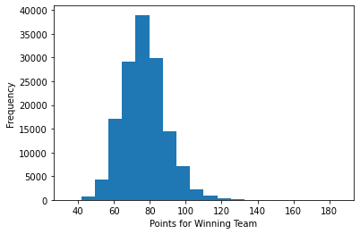

```python
ax = df['Wscore'].plot.hist(bins=20)
ax.set_xlabel('Points for Winning Team')
plt.show()
```

## CSV 파일로 데이터프레임 저장

to_csv()사용 -> 데이터 프레임-> csv로 쉽게 저장

```python
# 결측치 있는 데이터프레임 -> 결측치 0으로 변경 후 저장
df1.fillna(0).to_csv('test.csv') #test.csv로 저장
df2 = pd.read_csv('test.csv')
df2
#불러오면서 인덱스 중복 발생 -> 불러올때 첫번째 열 인덱스 지정해 부르기 or 처음부터 빼고 저장
```

|  | Unnamed: 0 | name | sn | mid | final | quiz |
| --- | --- | --- | --- | --- | --- | --- |
| 0 | 0 | Park | 1001 | 70.0 | 60.0 | 10 |
| 1 | 1 | Kim | 1002 | 80.0 | 75.0 | 10 |
| 2 | 2 | Lee | 1003 | 0.0 | 0.0 | 10 |
| 3 | 3 | Kang | 1004 | 90.0 | 49.0 | 10 |

```python
#인덱스 제외하고 저장하는 방법
df1.fillna(0).to_csv('test.csv', index=False) #인덱스를 저장하지 않음
df2 = pd.read_csv('test.csv')
df2
```

|  | name | sn | mid | final | quiz |
| --- | --- | --- | --- | --- | --- |
| 0 | Park | 1001 | 70.0 | 60.0 | 10 |
| 1 | Kim | 1002 | 80.0 | 75.0 | 10 |
| 2 | Lee | 1003 | 0.0 | 0.0 | 10 |
| 3 | Kang | 1004 | 90.0 | 49.0 | 10 |

```python
#첫 열을 인덱스로 읽어들이는 방법
df1.fillna(0).to_csv('test.csv')
df2 = pd.read_csv('test.csv', index_col=0) #첫 열을 인덱스로 저장
df2
```

|  | name | sn | mid | final | quiz |
| --- | --- | --- | --- | --- | --- |
| 0 | Park | 1001 | 70.0 | 60.0 | 10 |
| 1 | Kim | 1002 | 80.0 | 75.0 | 10 |
| 2 | Lee | 1003 | 0.0 | 0.0 | 10 |
| 3 | Kang | 1004 | 90.0 | 49.0 | 10 |